# FinalProject_Leena_6020

### Car Insurance Claim Prediction

Predicting car insurance claims is crucial for insurers to optimize pricing, manage risk, and reduce financial losses. This project leverages machine learning to forecast claim likelihood within 6 months using policyholder and vehicle data.

Below is a structured analysis of the problem, dataset, and relevant literature:

#### Problem Definition:

The Car Insurance Claim Prediction project addresses a critical challenge faced by insurance companies: accurately forecasting the likelihood of policyholders filing claims within a 6-month period. This problem is significant due to several factors:

- Rising accident severity: There has been a 21% increase in accident severity from 2010 to 2019, making risk assessment more complex.
- Increasing operational costs: Insurance companies need to optimize their processes to remain competitive.
- Complex interactions: Traditional actuarial methods often fail to account for the intricate relationships between vehicle safety features, policyholder demographics, and regional risk factors.

Accurate claim prediction enables insurance companies to:

- Implement dynamic premium pricing strategies
- Enhance fraud detection capabilities (potentially saving $308B annually on a global scale)
- Optimize resource allocation for claims processing
- Recent literature has shown that machine learning approaches can significantly improve the accuracy of insurance claim predictions compared to traditional statistical methods. These advanced techniques can capture non-linear relationships and complex interactions between variables, leading to more precise risk assessments.

### Dataset Description

##### Source & Structure

The dataset used for this analysis is sourced from Kaggle and is titled "Car Insurance Claim Prediction." It contains information on 58,592 insurance policies, each described by 44 variables that include both categorical and numerical features1. The dataset encompasses a wide range of information about policyholders, their vehicles, and various risk factors.

Key features of the dataset include:

- Policy details: policy ID, tenure
- Policyholder information: age
- Vehicle characteristics: age, make, model, segment, fuel type, engine specifications
- Safety features: airbags, ESC, TPMS, parking sensors/camera
- Geographical data: area cluster, population density
- Vehicle specifications: dimensions, weight, transmission type
- Safety ratings: NCAP rating

The target variable is 'is_claim', a binary indicator of whether a claim was filed (1) or not (0) within the 6-month period.

This dataset is particularly suitable for predictive analysis in the insurance domain as it provides a comprehensive view of factors that may influence claim likelihood. It allows for the exploration of complex relationships between vehicle characteristics, policyholder attributes, and claim occurrence.

Importing libraries

```python
import pandas as pd
import numpy as np
import os
import pickle
import matplotlib.pyplot as plt
import seaborn as sns
from scipy.stats import ttest_ind, mannwhitneyu
import plotly.express as px
from statsmodels.stats.outliers_influence import variance_inflation_factor
import time
from sklearn.utils import resample
from sklearn.neighbors import KNeighborsClassifier
from sklearn.model_selection import train_test_split, GridSearchCV, RandomizedSearchCV
from sklearn.preprocessing import OneHotEncoder, StandardScaler
from sklearn.linear_model import LogisticRegression
from sklearn.tree import DecisionTreeClassifier, plot_tree
from sklearn.metrics import accuracy_score, classification_report, confusion_matrix, roc_auc_score, roc_curve, precision_score, recall_score, f1_score, auc
from sklearn.ensemble import RandomForestClassifier
from xgboost import XGBClassifier
from sklearn.svm import SVC
import warnings
warnings.filterwarnings('ignore')
pd.set_option('display.max_rows', 100)
pd.set_option('display.max_columns', 100)
from scipy import stats
import random
random.seed(42)
import plotly.io as pio
pio.renderers.default = "notebook"
```

```python
# Load the dataset
data = pd.read_csv('D:/Naira Documents/Northeastern University/Assignments/ALY6020/Final Proj/finalproject/Src/Car_Insurance.csv')

# Descriptive statistics
descriptive_stats = data.describe(include='all')
print(descriptive_stats)
```

```
       policy_id  policy_tenure    age_of_car  age_of_policyholder  \
count      58592   58592.000000  58592.000000         58592.000000
unique     58592            NaN           NaN                  NaN
top      ID00001            NaN           NaN                  NaN
freq           1            NaN           NaN                  NaN
mean         NaN       0.611246      0.069424             0.469420
std          NaN       0.414156      0.056721             0.122886
min          NaN       0.002735      0.000000             0.288462
25%          NaN       0.210250      0.020000             0.365385
50%          NaN       0.573792      0.060000             0.451923
75%          NaN       1.039104      0.110000             0.548077
max          NaN       1.396641      1.000000             1.000000

       area_cluster  population_density          make segment  model  \
count         58592        58592.000000  58592.000000   58592  58592
unique           22                 NaN           NaN       6     11
top              C8                 NaN           NaN      B2     M1
freq          13654                 NaN           NaN   18314  14948
mean            NaN        18826.858667      1.763722     NaN    NaN
std             NaN        17660.174792      1.136988     NaN    NaN
min             NaN          290.000000      1.000000     NaN    NaN
25%             NaN         6112.000000      1.000000     NaN    NaN
50%             NaN         8794.000000      1.000000     NaN    NaN
75%             NaN        27003.000000      3.000000     NaN    NaN
max             NaN        73430.000000      5.000000     NaN    NaN

       fuel_type     max_torque         max_power        engine_type  \
count      58592          58592             58592              58592
unique         3              9                 9                 11
top       Petrol  113Nm@4400rpm  88.50bhp@6000rpm  F8D Petrol Engine
freq       20532          17796             17796              14948
mean         NaN            NaN               NaN                NaN
std          NaN            NaN               NaN                NaN
min          NaN            NaN               NaN                NaN
25%          NaN            NaN               NaN                NaN
50%          NaN            NaN               NaN                NaN
75%          NaN            NaN               NaN                NaN
max          NaN            NaN               NaN                NaN

             airbags is_esc is_adjustable_steering is_tpms is_parking_sensors  \
```

[output cut: 100 more lines]

```
75%                              NaN    NaN            NaN      3.000000
max                              NaN    NaN            NaN      5.000000

            is_claim
count   58592.000000
unique           NaN
top              NaN
freq             NaN
mean        0.172157
std         0.377520
min         0.000000
25%         0.000000
50%         0.000000
75%         0.000000
max         1.000000
```

```python
data.describe()
```

|  | policy_tenure | age_of_car | age_of_policyholder | population_density | make | airbags | displacement | cylinder | gear_box | turning_radius | length | width | height | gross_weight | ncap_rating | is_claim |
| --- | --- | --- | --- | --- | --- | --- | --- | --- | --- | --- | --- | --- | --- | --- | --- | --- |
| count | 58592.000000 | 58592.000000 | 58592.000000 | 58592.000000 | 58592.000000 | 58592.000000 | 58592.000000 | 58592.000000 | 58592.000000 | 58592.000000 | 58592.000000 | 58592.000000 | 58592.00000 | 58592.000000 | 58592.000000 | 58592.000000 |
| mean | 0.611246 | 0.069424 | 0.469420 | 18826.858667 | 1.763722 | 3.137066 | 1162.355851 | 3.626963 | 5.245443 | 4.852893 | 3850.476891 | 1672.233667 | 1553.33537 | 1385.276813 | 1.759950 | 0.172157 |
| std | 0.414156 | 0.056721 | 0.122886 | 17660.174792 | 1.136988 | 1.832641 | 266.304786 | 0.483616 | 0.430353 | 0.228061 | 311.457119 | 112.089135 | 79.62227 | 212.423085 | 1.389576 | 0.377520 |
| min | 0.002735 | 0.000000 | 0.288462 | 290.000000 | 1.000000 | 1.000000 | 796.000000 | 3.000000 | 5.000000 | 4.500000 | 3445.000000 | 1475.000000 | 1475.00000 | 1051.000000 | 0.000000 | 0.000000 |
| 25% | 0.210250 | 0.020000 | 0.365385 | 6112.000000 | 1.000000 | 2.000000 | 796.000000 | 3.000000 | 5.000000 | 4.600000 | 3445.000000 | 1515.000000 | 1475.00000 | 1185.000000 | 0.000000 | 0.000000 |
| 50% | 0.573792 | 0.060000 | 0.451923 | 8794.000000 | 1.000000 | 2.000000 | 1197.000000 | 4.000000 | 5.000000 | 4.800000 | 3845.000000 | 1735.000000 | 1530.00000 | 1335.000000 | 2.000000 | 0.000000 |
| 75% | 1.039104 | 0.110000 | 0.548077 | 27003.000000 | 3.000000 | 6.000000 | 1493.000000 | 4.000000 | 5.000000 | 5.000000 | 3995.000000 | 1755.000000 | 1635.00000 | 1510.000000 | 3.000000 | 0.000000 |
| max | 1.396641 | 1.000000 | 1.000000 | 73430.000000 | 5.000000 | 6.000000 | 1498.000000 | 4.000000 | 6.000000 | 5.200000 | 4300.000000 | 1811.000000 | 1825.00000 | 1720.000000 | 5.000000 | 1.000000 |

### Missing Values:

The dataset contains no missing values across all columns .

```python
# Check for missing values
missing_values = data.isnull().sum()
missing_values
```

```
policy_id                           0
policy_tenure                       0
age_of_car                          0
age_of_policyholder                 0
area_cluster                        0
population_density                  0
make                                0
segment                             0
model                               0
fuel_type                           0
max_torque                          0
max_power                           0
engine_type                         0
airbags                             0
is_esc                              0
is_adjustable_steering              0
is_tpms                             0
is_parking_sensors                  0
is_parking_camera                   0
rear_brakes_type                    0
displacement                        0
cylinder                            0
transmission_type                   0
gear_box                            0
steering_type                       0
turning_radius                      0
length                              0
width                               0
height                              0
gross_weight                        0
is_front_fog_lights                 0
is_rear_window_wiper                0
is_rear_window_washer               0
is_rear_window_defogger             0
is_brake_assist                     0
is_power_door_locks                 0
is_central_locking                  0
is_power_steering                   0
is_driver_seat_height_adjustable    0
is_day_night_rear_view_mirror       0
is_ecw                              0
is_speed_alert                      0
ncap_rating                         0
is_claim                            0
dtype: int64
```

```python
# Ensure max_torque and max_power columns are strings before extraction
data['max_torque'] = data['max_torque'].astype(str).str.extract('(\d+\.?\d*)').astype(float)
data['max_power'] = data['max_power'].astype(str).str.extract('(\d+\.?\d*)').astype(float)
```

```python
data['is_claim'].value_counts()
```

```
is_claim
0    48505
1    10087
Name: count, dtype: int64
```

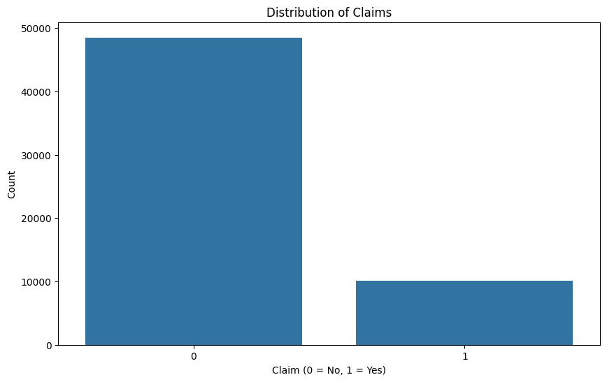

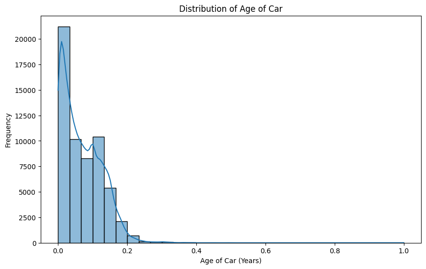

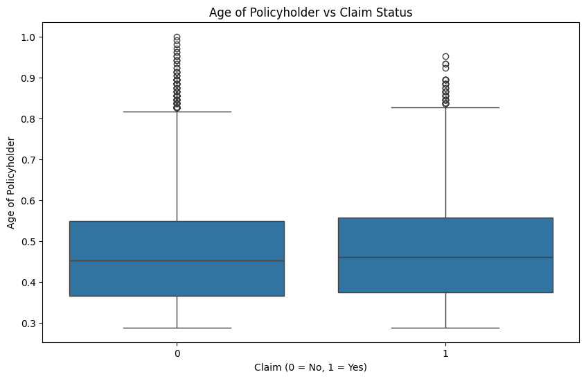

```python
# Visualizations
plt.figure(figsize=(10, 6))
sns.countplot(x='is_claim', data=data)
plt.title('Distribution of Claims')
plt.xlabel('Claim (0 = No, 1 = Yes)')
plt.ylabel('Count')
plt.show()

plt.figure(figsize=(10, 6))
sns.histplot(data['age_of_car'], kde=True, bins=30)
plt.title('Distribution of Age of Car')
plt.xlabel('Age of Car (Years)')
plt.ylabel('Frequency')
plt.show()

plt.figure(figsize=(10, 6))
sns.boxplot(x='is_claim', y='age_of_policyholder', data=data)
plt.title('Age of Policyholder vs Claim Status')
plt.xlabel('Claim (0 = No, 1 = Yes)')
plt.ylabel('Age of Policyholder')
plt.show()
```

#### Exploratory Data Analysis (EDA)

The EDA reveals several important insights about the dataset:

1. Class Imbalance: The target variable 'is_claim' shows significant imbalance, with only 17.22% of policies resulting in a claim1. This imbalance will need to be addressed in the modeling phase to ensure fair predictions.
2. Numerical Features: Policy tenure ranges from 0.003 to 1.397 years, with a mean of 0.611 years1. Vehicle age ranges from 0 to 1 year, with a mean of 0.069 years, indicating a relatively new fleet1. Policyholder age (normalized) ranges from 0.288 to 1, with a mean of 0.4691.
3. Categorical Features: The dataset includes 22 unique area clusters, with 'C8' being the most common (13,654 policies)1. There are 6 vehicle segments, with 'B2' being the most frequent (18,314 policies)1. 11 different models are represented, with 'M1' being the most common (14,948 policies)
4. Vehicle Characteristics: Petrol is the most common fuel type (20,532 vehicles)1. The majority of vehicles have 2 airbags, with a range from 1 to 61. Most vehicles do not have ESC (Electronic Stability Control) (40,191 without vs. 18,401 with)
5. Safety Features: The majority of vehicles have parking sensors (56,219) but lack a parking camera (35,704 without) NCAP ratings range from 0 to 5, with a mean of 1.76, indicating room for safety improvements across the fleet

These insights provide a foundation for feature engineering and selection in the subsequent modeling phase. The class imbalance, in particular, suggests that techniques like SMOTE or class weighting may be necessary to ensure fair model performance.

### Outlier Check

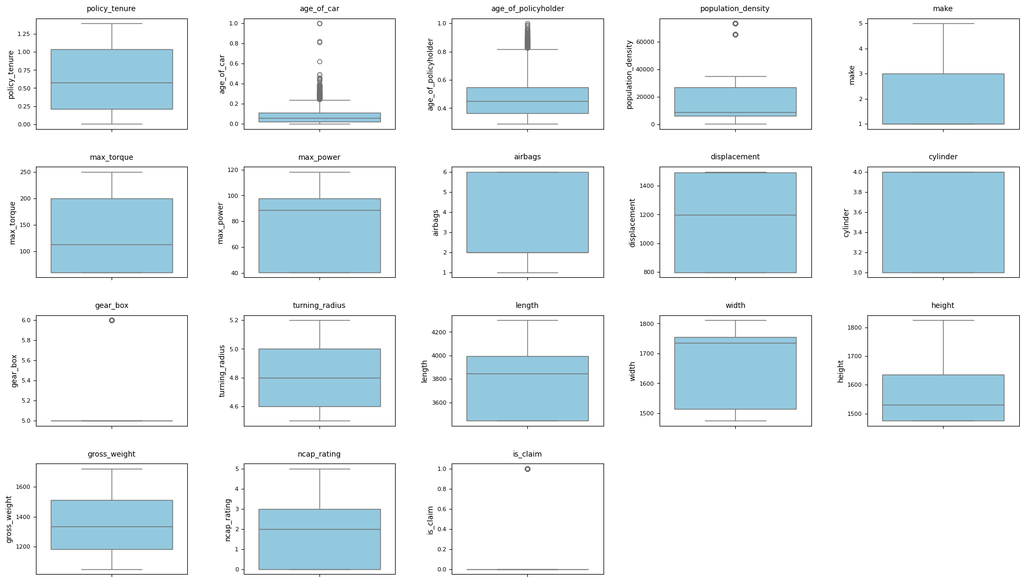

```python
# Select numerical columns
numeric_cols = data.select_dtypes(include=['float64', 'int64']).columns

# Create individual box plots for each numerical variable
plt.figure(figsize=(20, 20))

# Create a 7x5 grid of subplots to accommodate all 31 variables
for i, col in enumerate(numeric_cols, 1):
    plt.subplot(7, 5, i)
    sns.boxplot(data=data, y=col, color='skyblue')
    plt.title(col, pad=10, fontsize=10)
    plt.xticks(fontsize=8)
    plt.yticks(fontsize=8)

plt.tight_layout(pad=3.0)
plt.show()
```

Based on the boxplot visualization, here's a comprehensive analysis of outliers and recommended treatments:

Variables with Significant Outliers

- Continuous Variables
  1. population_density
     - Shows extreme upper outliers
     - Treatment: Apply log transformation
- Age-Related Variables
  1. age_of_car
     - Few upper outliers
     - Treatment: Cap at 99th percentile
  2. age_of_policyholder
     - Moderate outliers
     - Treatment: Cap at 99th percentile

```python
def treat_outliers(df):
    treated_df = df.copy()

    # Population density treatment with explicit lower bound
    treated_df['population_density_log'] = np.log1p(treated_df['population_density'])
    treated_df['population_density_log'] = treated_df['population_density_log'].clip(lower=7)

    # Other variable treatments remain the same
    continuous_vars = ['max_torque', 'max_power', 'displacement']
    for col in continuous_vars:
        upper_limit = treated_df[col].quantile(0.95)
        treated_df[col] = treated_df[col].clip(upper=upper_limit)

    age_vars = ['age_of_car', 'age_of_policyholder']
    for col in age_vars:
        upper_limit = treated_df[col].quantile(0.99)
        treated_df[col] = treated_df[col].clip(upper=upper_limit)

    return treated_df
```

1. Log Transformation for population_density
- Purpose: The population_density variable may have a skewed distribution with extreme values.
- Transformation Applied: np.log1p(x) = log(x + 1) is used to compress large values and reduce skewness.
- Clipping: The lower bound is set at 7 to ensure no extremely small values.
2. Clipping Outliers for Continuous Variables
- Purpose: Continuous variables (max_torque, max_power, and displacement) often have extreme values that could distort model predictions.

Method:

- The 95th percentile (quantile(0.95)) is computed.
- Any value above this limit is clipped to the upper limit.
3. Clipping Outliers for Age-Related Variables
- Purpose: Variables like age_of_car and age_of_policyholder might have a few extreme values.

Method:

- The 99th percentile (quantile(0.99)) is used as the threshold.
- Any value above this limit is clipped.

Key Takeaways Log Transformation: Applied to population_density to manage skewed data. Clipping: Used to cap extreme values in continuous variables. Percentile-Based Limits: Ensures outlier handling is based on data distribution rather than arbitrary thresholds.

```python
data.head()
```

|  | policy_id | policy_tenure | age_of_car | age_of_policyholder | area_cluster | population_density | make | segment | model | fuel_type | max_torque | max_power | engine_type | airbags | is_esc | is_adjustable_steering | is_tpms | is_parking_sensors | is_parking_camera | rear_brakes_type | displacement | cylinder | transmission_type | gear_box | steering_type | turning_radius | length | width | height | … |
| --- | --- | --- | --- | --- | --- | --- | --- | --- | --- | --- | --- | --- | --- | --- | --- | --- | --- | --- | --- | --- | --- | --- | --- | --- | --- | --- | --- | --- | --- | --- |
| 0 | ID00001 | 0.515874 | 0.05 | 0.644231 | C1 | 4990 | 1 | A | M1 | CNG | 60.0 | 40.36 | F8D Petrol Engine | 2 | No | No | No | Yes | No | Drum | 796 | 3 | Manual | 5 | Power | 4.6 | 3445 | 1515 | 1475 | … |
| 1 | ID00002 | 0.672619 | 0.02 | 0.375000 | C2 | 27003 | 1 | A | M1 | CNG | 60.0 | 40.36 | F8D Petrol Engine | 2 | No | No | No | Yes | No | Drum | 796 | 3 | Manual | 5 | Power | 4.6 | 3445 | 1515 | 1475 | … |
| 2 | ID00003 | 0.841110 | 0.02 | 0.384615 | C3 | 4076 | 1 | A | M1 | CNG | 60.0 | 40.36 | F8D Petrol Engine | 2 | No | No | No | Yes | No | Drum | 796 | 3 | Manual | 5 | Power | 4.6 | 3445 | 1515 | 1475 | … |
| 3 | ID00004 | 0.900277 | 0.11 | 0.432692 | C4 | 21622 | 1 | C1 | M2 | Petrol | 113.0 | 88.50 | 1.2 L K12N Dualjet | 2 | Yes | Yes | No | Yes | Yes | Drum | 1197 | 4 | Automatic | 5 | Electric | 4.8 | 3995 | 1735 | 1515 | … |
| 4 | ID00005 | 0.596403 | 0.11 | 0.634615 | C5 | 34738 | 2 | A | M3 | Petrol | 91.0 | 67.06 | 1.0 SCe | 2 | No | No | No | No | Yes | Drum | 999 | 3 | Automatic | 5 | Electric | 5.0 | 3731 | 1579 | 1490 | … |

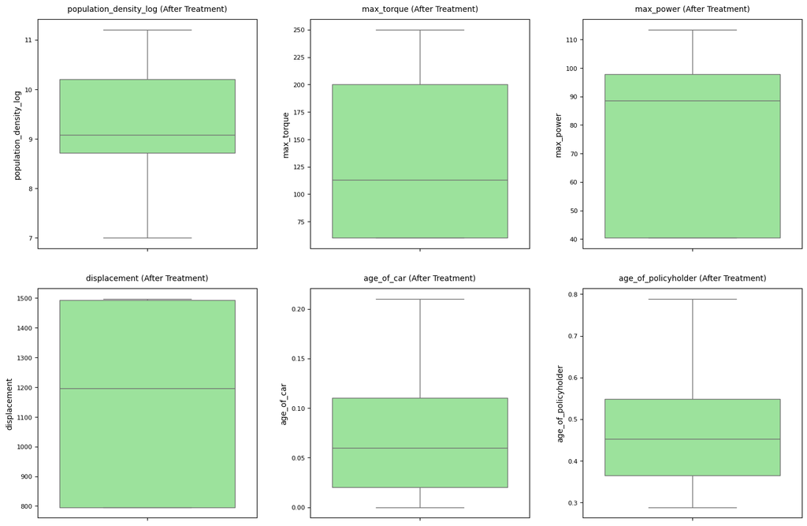

```python
# Apply treatments and visualize
treated_data = treat_outliers(data)

# Visualize treated variables
treated_vars = ['population_density_log', 'max_torque', 'max_power',
                'displacement', 'age_of_car', 'age_of_policyholder']

plt.figure(figsize=(15, 10))
for i, col in enumerate(treated_vars, 1):
    plt.subplot(2, 3, i)
    sns.boxplot(data=treated_data, y=col, color='lightgreen')
    plt.title(f'{col} (After Treatment)', pad=10, fontsize=10)
    plt.xticks(fontsize=8)
    plt.yticks(fontsize=8)

plt.tight_layout(pad=3.0)
plt.show()
```

```python
# Drop the 'population_density' column from the dataset
treated_data = treated_data.drop(columns=['population_density'])

# Verify the column has been dropped
print(treated_data.columns)
```

```
Index(['policy_id', 'policy_tenure', 'age_of_car', 'age_of_policyholder',
       'area_cluster', 'make', 'segment', 'model', 'fuel_type', 'max_torque',
       'max_power', 'engine_type', 'airbags', 'is_esc',
       'is_adjustable_steering', 'is_tpms', 'is_parking_sensors',
       'is_parking_camera', 'rear_brakes_type', 'displacement', 'cylinder',
       'transmission_type', 'gear_box', 'steering_type', 'turning_radius',
       'length', 'width', 'height', 'gross_weight', 'is_front_fog_lights',
       'is_rear_window_wiper', 'is_rear_window_washer',
       'is_rear_window_defogger', 'is_brake_assist', 'is_power_door_locks',
       'is_central_locking', 'is_power_steering',
       'is_driver_seat_height_adjustable', 'is_day_night_rear_view_mirror',
       'is_ecw', 'is_speed_alert', 'ncap_rating', 'is_claim',
       'population_density_log'],
      dtype='object')
```

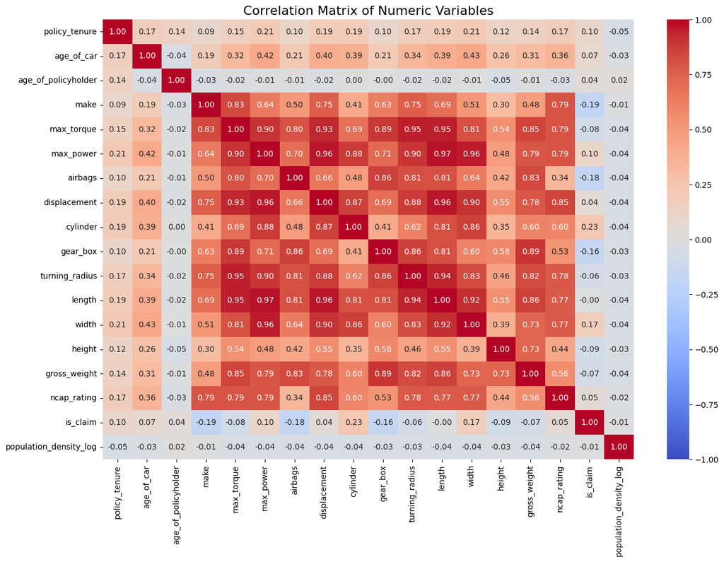

|  | policy_tenure | age_of_car | age_of_policyholder | make | max_torque | max_power | airbags | displacement | cylinder | gear_box | turning_radius | length | width | height | gross_weight | ncap_rating | is_claim | population_density_log |
| --- | --- | --- | --- | --- | --- | --- | --- | --- | --- | --- | --- | --- | --- | --- | --- | --- | --- | --- |
| policy_tenure | 1.000000 | 0.168522 | 0.143293 | 0.086101 | 0.150604 | 0.207331 | 0.103981 | 0.194386 | 0.191185 | 0.095305 | 0.166426 | 0.190869 | 0.213228 | 0.119055 | 0.141027 | 0.173280 | 0.098297 | -0.050725 |
| age_of_car | 0.168522 | 1.000000 | -0.041296 | 0.192722 | 0.316452 | 0.421110 | 0.214681 | 0.403723 | 0.390237 | 0.206155 | 0.341629 | 0.393413 | 0.425654 | 0.264656 | 0.308916 | 0.357693 | 0.073923 | -0.025622 |
| age_of_policyholder | 0.143293 | -0.041296 | 1.000000 | -0.032260 | -0.016376 | -0.013044 | -0.008551 | -0.024793 | 0.003090 | -0.003595 | -0.017692 | -0.021213 | -0.007391 | -0.054656 | -0.008476 | -0.032568 | 0.035220 | 0.022043 |
| make | 0.086101 | 0.192722 | -0.032260 | 1.000000 | 0.829837 | 0.642587 | 0.501800 | 0.753087 | 0.410672 | 0.632807 | 0.753861 | 0.692365 | 0.511695 | 0.303274 | 0.481408 | 0.792254 | -0.192795 | -0.010759 |
| max_torque | 0.150604 | 0.316452 | -0.016376 | 0.829837 | 1.000000 | 0.899044 | 0.800408 | 0.931271 | 0.685863 | 0.885212 | 0.946552 | 0.952065 | 0.806807 | 0.540861 | 0.850068 | 0.792789 | -0.081260 | -0.036366 |
| max_power | 0.207331 | 0.421110 | -0.013044 | 0.642587 | 0.899044 | 1.000000 | 0.696295 | 0.963960 | 0.878574 | 0.711487 | 0.896585 | 0.973914 | 0.959660 | 0.482280 | 0.786984 | 0.793821 | 0.104052 | -0.043998 |
| airbags | 0.103981 | 0.214681 | -0.008551 | 0.501800 | 0.800408 | 0.696295 | 1.000000 | 0.661387 | 0.478594 | 0.859556 | 0.810820 | 0.809094 | 0.639562 | 0.423816 | 0.828988 | 0.341557 | -0.176003 | -0.036396 |
| displacement | 0.194386 | 0.403723 | -0.024793 | 0.753087 | 0.931271 | 0.963960 | 0.661387 | 1.000000 | 0.866274 | 0.692435 | 0.875528 | 0.961756 | 0.899428 | 0.554775 | 0.776555 | 0.846992 | 0.042305 | -0.039504 |
| cylinder | 0.191185 | 0.390237 | 0.003090 | 0.410672 | 0.685863 | 0.878574 | 0.478594 | 0.866274 | 1.000000 | 0.410163 | 0.615806 | 0.805476 | 0.862430 | 0.352118 | 0.602978 | 0.598364 | 0.229763 | -0.042999 |
| gear_box | 0.095305 | 0.206155 | -0.003595 | 0.632807 | 0.885212 | 0.711487 | 0.859556 | 0.692435 | 0.410163 | 1.000000 | 0.861740 | 0.808975 | 0.601923 | 0.579725 | 0.894639 | 0.529688 | -0.163858 | -0.034101 |
| turning_radius | 0.166426 | 0.341629 | -0.017692 | 0.753861 | 0.946552 | 0.896585 | 0.810820 | 0.875528 | 0.615806 | 0.861740 | 1.000000 | 0.944899 | 0.825603 | 0.460436 | 0.823097 | 0.779302 | -0.064700 | -0.034624 |
| length | 0.190869 | 0.393413 | -0.021213 | 0.692365 | 0.952065 | 0.973914 | 0.809094 | 0.961756 | 0.805476 | 0.808975 | 0.944899 | 1.000000 | 0.915918 | 0.553579 | 0.861723 | 0.767519 | -0.000830 | -0.042507 |
| width | 0.213228 | 0.425654 | -0.007391 | 0.511695 | 0.806807 | 0.959660 | 0.639562 | 0.899428 | 0.862430 | 0.601923 | 0.825603 | 0.915918 | 1.000000 | 0.389317 | 0.734284 | 0.771944 | 0.166925 | -0.044755 |
| height | 0.119055 | 0.264656 | -0.054656 | 0.303274 | 0.540861 | 0.482280 | 0.423816 | 0.554775 | 0.352118 | 0.579725 | 0.460436 | 0.553579 | 0.389317 | 1.000000 | 0.728377 | 0.437182 | -0.085302 | -0.029748 |
| gross_weight | 0.141027 | 0.308916 | -0.008476 | 0.481408 | 0.850068 | 0.786984 | 0.828988 | 0.776555 | 0.602978 | 0.894639 | 0.823097 | 0.861723 | 0.734284 | 0.728377 | 1.000000 | 0.556270 | -0.065305 | -0.042059 |
| ncap_rating | 0.173280 | 0.357693 | -0.032568 | 0.792254 | 0.792789 | 0.793821 | 0.341557 | 0.846992 | 0.598364 | 0.529688 | 0.779302 | 0.767519 | 0.771944 | 0.437182 | 0.556270 | 1.000000 | 0.051970 | -0.023425 |
| is_claim | 0.098297 | 0.073923 | 0.035220 | -0.192795 | -0.081260 | 0.104052 | -0.176003 | 0.042305 | 0.229763 | -0.163858 | -0.064700 | -0.000830 | 0.166925 | -0.085302 | -0.065305 | 0.051970 | 1.000000 | -0.013579 |
| population_density_log | -0.050725 | -0.025622 | 0.022043 | -0.010759 | -0.036366 | -0.043998 | -0.036396 | -0.039504 | -0.042999 | -0.034101 | -0.034624 | -0.042507 | -0.044755 | -0.029748 | -0.042059 | -0.023425 | -0.013579 | 1.000000 |

```python
# Select only numeric columns
numeric_data = treated_data.select_dtypes(include=['float64', 'int64'])

# Calculate the correlation matrix for numeric variables
correlation_matrix = numeric_data.corr()

# Plot heatmap of the correlation matrix
plt.figure(figsize=(15, 10))
sns.heatmap(correlation_matrix, annot=True, fmt='.2f', cmap='coolwarm', center=0, vmin=-1, vmax=1)
plt.title("Correlation Matrix of Numeric Variables", fontsize=16)
plt.show()

correlation_matrix
```

The correlation matrix provides insights into the relationships between numeric variables in my dataset. Here's a detailed analysis based on the provided image:

Key Observations

Target Variable (is_claim)

The correlations between is_claim and other variables remain weak, with the highest being:

- cylinder (r = 0.23): Indicates a modest relationship with claims.
- width (r = 0.17): Suggests a slight association with claims.
- max_power (r = 0.10): Shows limited predictive power for claims.
- This indicates that no single variable strongly predicts whether a claim is made, reinforcing the need for feature combinations or advanced feature engineering.

Population Density

Feature Groups

- Vehicle Dimensions:
  - Features like length, width, and height are moderately to highly correlated with each other.
  - Consider retaining only one or two of these features to reduce multicollinearity.

Engine Specifications:

- Features like max_torque, max_power, and displacement are highly correlated, reflecting their interdependence in vehicle performance.
- Select one representative feature or use dimensionality reduction techniques.

Weak Correlations:

Recommendations

1. Feature Selection Drop highly correlated features to reduce multicollinearity: Retain either max_torque, displacement, or max_power. Retain either length or width. Use techniques like Principal Component Analysis (PCA) or Variance Inflation Factor (VIF) to identify redundant features.
2. Target Variable (is_claim) Since no single variable strongly correlates with the target variable: Focus on combining multiple features in your model. Experiment with interaction terms or non-linear transformations to capture complex relationships.
3. Log Transformation Retain only the log-transformed version of population density (population_density_log) as it reduces skewness while maintaining relationships with other variables.
4. Modeling Implications Use regularization techniques like Lasso or Ridge regression to handle multicollinearity. Consider ensemble methods such as Random Forest or Gradient Boosting, which are less sensitive to feature correlations. Explore tree-based models that can automatically handle non-linear relationships and interactions among features.

#### Conclusion

The updated correlation matrix highlights strong relationships among some features, suggesting potential redundancy, while also showing weak individual correlations with the target variable (is_claim). A careful combination of feature selection, transformation, and advanced modeling techniques will be essential for building an effective predictive model for car insurance claims.

```python
# Set correlation threshold (e.g., 0.9)
correlation_threshold = 0.9

# Create a mask to identify highly correlated features
correlation_matrix = numeric_data.corr()
# Create an upper triangle of the correlation matrix (since it's symmetric)
upper_triangle = correlation_matrix.where(np.triu(np.ones(correlation_matrix.shape), k=1).astype(bool))

# Get columns with correlation greater than the threshold
to_drop = [column for column in upper_triangle.columns if any(upper_triangle[column] > correlation_threshold)]

# Drop highly correlated features
selected_data = numeric_data.drop(columns=to_drop)

# Output the features that were dropped
print("Dropped Features due to High Correlation:", to_drop)

# Show the final set of selected features
print("Selected Features:", selected_data.columns.tolist())
```

```
Dropped Features due to High Correlation: ['displacement', 'turning_radius', 'length', 'width']
Selected Features: ['policy_tenure', 'age_of_car', 'age_of_policyholder', 'make', 'max_torque', 'max_power', 'airbags', 'cylinder', 'gear_box', 'height', 'gross_weight', 'ncap_rating', 'is_claim', 'population_density_log']
```

```python
treated_data['is_claim'].value_counts(normalize=True)
```

```
is_claim
0    0.827843
1    0.172157
Name: proportion, dtype: float64
```

# Undersmapling

```python
from sklearn.utils import resample

# Split the data into majority (class 0) and minority (class 1)
majority_class = treated_data[treated_data['is_claim'] == 0]
minority_class = treated_data[treated_data['is_claim'] == 1]
undersample_sample = int(len(majority_class)*0.7)
# Undersample the majority class
majority_class_undersampled = resample(majority_class,
                                       replace=False,     # Don't allow resampling within the majority class
                                       n_samples= undersample_sample, #len(minority_class),  # Match the size of the minority class
                                       random_state=42)   # Ensure reproducibility

# Combine the undersampled majority class with the original minority class
undersampled_data = pd.concat([majority_class_undersampled, minority_class])

# Check the new class distribution
print(undersampled_data['is_claim'].value_counts())
```

```
is_claim
0    33953
1    10087
Name: count, dtype: int64
```

#### Undersampling steps:

Splitting the Data:

- The data is split into two subsets based on the target variable is_claim:
- majority_class: Records where is_claim = 0 (non-claims).
- minority_class: Records where is_claim = 1 (claims).

Undersampling the Majority Class:

- The majority class (is_claim = 0) is undersampled to reduce its size.
- The number of samples in the undersampled majority class is set to 70% of its original size (int(len(majority_class) * 0.7)).
- The resample function ensures no replacement (replace=False), so no duplicate rows are introduced during undersampling.

Combining Classes:

- The undersampled majority class is combined with the original minority class to create a new dataset, undersampled_data.

Class Distribution:

- After undersampling, the new class distribution is:
  - Class 0 (non-claims): 33,953 samples
  - Class 1 (claims): 10,087 samples

Key Observations

Original Class Imbalance:

- Before undersampling, the dataset likely had a significant imbalance, with many more records for is_claim = 0 compared to is_claim = 1.

Undersampling Effect:

- By reducing the size of the majority class to 70% of its original size, the imbalance has been mitigated.

However, there is still a noticeable difference between the two classes (33,953 vs. 10,087). This approach strikes a balance between addressing imbalance and retaining sufficient data for training.

Class Ratio After Undersampling:

- The new ratio of majority to minority class is approximately 3.37:1, which is an improvement over the original imbalance.

Impact on Model Training:

- Undersampling reduces bias toward the majority class by ensuring that both classes are better represented during training.
- However, it also removes some data from the majority class, which may lead to a loss of information.

```python
# Handle remaining boolean and categorical columns
boolean_columns = ['is_esc', 'is_adjustable_steering', 'is_tpms', 'is_parking_sensors',
                   'is_parking_camera', 'is_front_fog_lights', 'is_rear_window_wiper',
                   'is_rear_window_washer', 'is_rear_window_defogger', 'is_brake_assist',
                   'is_power_door_locks', 'is_central_locking', 'is_power_steering',
                   'is_driver_seat_height_adjustable', 'is_day_night_rear_view_mirror',
                   'is_ecw', 'is_speed_alert']

for col in boolean_columns:
    undersampled_data[col] = undersampled_data[col].map({'Yes': 1, 'No': 0})
```

```python
undersampled_data['rear_brakes_type']=undersampled_data['rear_brakes_type'].replace({'Drum':0,'Disc':1})
undersampled_data['transmission_type']=undersampled_data['transmission_type'].replace({'Manual':0,'Automatic':1})
```

```python
undersampled_data.drop(columns=['policy_id', 'area_cluster', 'model', 'segment'], inplace=True)
```

```python
# Check for categorical columns
categorical_columns = undersampled_data.select_dtypes(include=['object']).columns

# Display unique categories for each categorical column
for col in categorical_columns:
    print(f"Categories in {col}:")
    print(undersampled_data[col].value_counts())
    print("="*50)
```

[output not shown]

### One Hot Encoding

```python
# Perform One-Hot Encoding for the selected categorical columns
categorical_columns_to_encode = ['fuel_type', 'engine_type', 'steering_type']

# One-Hot Encoding
undersampled_data = pd.get_dummies(undersampled_data, columns=categorical_columns_to_encode, drop_first=True)

# Display the transformed dataset
undersampled_data.head()
```

|  | policy_tenure | age_of_car | age_of_policyholder | make | max_torque | max_power | airbags | is_esc | is_adjustable_steering | is_tpms | is_parking_sensors | is_parking_camera | rear_brakes_type | displacement | cylinder | transmission_type | gear_box | turning_radius | length | width | height | gross_weight | is_front_fog_lights | is_rear_window_wiper | is_rear_window_washer | is_rear_window_defogger | is_brake_assist | is_power_door_locks | is_central_locking | … |
| --- | --- | --- | --- | --- | --- | --- | --- | --- | --- | --- | --- | --- | --- | --- | --- | --- | --- | --- | --- | --- | --- | --- | --- | --- | --- | --- | --- | --- | --- | --- |
| 57300 | 0.503926 | 0.06 | 0.336538 | 1 | 113.0 | 88.50 | 2 | 0 | 1 | 0 | 1 | 0 | 0 | 1197 | 4 | 0 | 5 | 4.8 | 3845 | 1735 | 1530 | 1335 | 1 | 0 | 0 | 0 | 1 | 1 | 1 | … |
| 46264 | 0.565006 | 0.06 | 0.644231 | 3 | 250.0 | 113.45 | 6 | 1 | 1 | 1 | 1 | 1 | 1 | 1493 | 4 | 1 | 6 | 5.2 | 4300 | 1790 | 1635 | 1720 | 1 | 1 | 1 | 1 | 1 | 1 | 1 | … |
| 28040 | 0.091208 | 0.03 | 0.509615 | 1 | 82.1 | 55.92 | 2 | 0 | 0 | 0 | 1 | 0 | 0 | 998 | 3 | 0 | 5 | 4.7 | 3655 | 1620 | 1675 | 1340 | 0 | 0 | 0 | 0 | 0 | 1 | 1 | … |
| 27218 | 0.319543 | 0.01 | 0.375000 | 1 | 60.0 | 40.36 | 2 | 0 | 0 | 0 | 1 | 0 | 0 | 796 | 3 | 0 | 5 | 4.6 | 3445 | 1515 | 1475 | 1185 | 0 | 0 | 0 | 0 | 0 | 0 | 0 | … |
| 7576 | 0.503931 | 0.04 | 0.365385 | 1 | 60.0 | 40.36 | 2 | 0 | 0 | 0 | 1 | 0 | 0 | 796 | 3 | 0 | 5 | 4.6 | 3445 | 1515 | 1475 | 1185 | 0 | 0 | 0 | 0 | 0 | 0 | 0 | … |

### Train Test Split

```python
# Define features (X) and target variable (y)
X = undersampled_data.drop(columns=['is_claim'])  # Drop target column
y = undersampled_data['is_claim']  # Target variable

# Split into train (80%) and test (20%) sets
X_train, X_test, y_train, y_test = train_test_split(X, y, test_size=0.2, random_state=42, stratify=y)

# Verify shape
print(X_train.shape, X_test.shape, y_train.shape, y_test.shape)
```

```
(35232, 50) (8808, 50) (35232,) (8808,)
```

The resulting shapes are:

- X_train: (35232, 50) - 35,232 samples with 50 features
- X_test: (8808, 50) - 8,808 samples with 50 features
- y_train and y_test have corresponding lengths

```python
num_cols = X_train.select_dtypes(include=['float64', 'int64']).columns
num_cols
```

```
Index(['policy_tenure', 'age_of_car', 'age_of_policyholder', 'make',
       'max_torque', 'max_power', 'airbags', 'is_esc',
       'is_adjustable_steering', 'is_tpms', 'is_parking_sensors',
       'is_parking_camera', 'rear_brakes_type', 'displacement', 'cylinder',
       'transmission_type', 'gear_box', 'turning_radius', 'length', 'width',
       'height', 'gross_weight', 'is_front_fog_lights', 'is_rear_window_wiper',
       'is_rear_window_washer', 'is_rear_window_defogger', 'is_brake_assist',
       'is_power_door_locks', 'is_central_locking', 'is_power_steering',
       'is_driver_seat_height_adjustable', 'is_day_night_rear_view_mirror',
       'is_ecw', 'is_speed_alert', 'ncap_rating', 'population_density_log'],
      dtype='object')
```

```python
X_train[num_cols] = StandardScaler().fit_transform(X_train[num_cols])
X_test[num_cols] = StandardScaler().fit_transform(X_test[num_cols])
```

##### Feature Scaling:

- StandardScaler is applied to the numerical columns (num_cols) of both X_train and X_test.
- This standardizes the features, giving them zero mean and unit variance.
- Scaling is important for many machine learning algorithms to perform optimally.

```python
# Create scaler pkl file
with open('../scripts/model/scaler.pkl', 'wb') as file:
    pickle.dump(StandardScaler(), file)
```

Scaler Persistence:

- A new StandardScaler object is created and saved as a pickle file.
- This allows for consistent scaling of new data in the future.

## Random Forest

```python
# Initialize model
rf_model = RandomForestClassifier(n_estimators=100, random_state=42)

# Train model
rf_model.fit(X_train, y_train)

# Make predictions
y_pred = rf_model.predict(X_test)

# Evaluate
print("Accuracy:", accuracy_score(y_test, y_pred))
print(classification_report(y_test, y_pred))
```

```
Accuracy: 0.8132379654859219
              precision    recall  f1-score   support

           0       0.86      0.90      0.88      6791
           1       0.61      0.53      0.56      2017

    accuracy                           0.81      8808
   macro avg       0.74      0.71      0.72      8808
weighted avg       0.81      0.81      0.81      8808
```

Model Performance

Accuracy:

- The Random Forest model achieved an accuracy of 81.32% on the test set.
- This indicates that the model correctly predicted 81.32% of the instances in the test set.

Precision, Recall, and F1-Score:

- For class 0 (no claim):
  - Precision: 0.86 (86% of predicted "no claims" were correct).
  - Recall: 0.90 (90% of actual "no claims" were identified correctly).
  - F1-score: 0.88 (good balance between precision and recall for this class).
- For class 1 (claim):
  - Precision: 0.61 (61% of predicted "claims" were correct).
  - Recall: 0.53 (53% of actual "claims" were identified correctly).
  - F1-score: 0.56 (moderate performance for this minority class).

The model performs well for the majority class (class 0) but struggles with the minority class (class 1), which is expected due to class imbalance.

- Macro Average:
  - F1-score: 0.72 This metric gives equal weight to both classes, showing moderate overall performance across both classes.
- Weighted Average:
  - F1-score: 0.81 This metric accounts for class imbalance, reflecting the strong performance on the majority class.

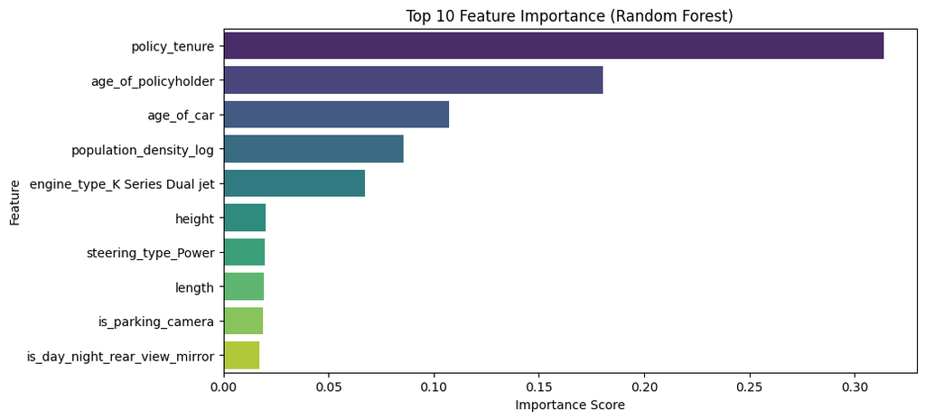

```python
# Get feature importance from the trained Random Forest model
feature_importance = rf_model.feature_importances_
feature_names = X.columns  # Use original feature names from X

# Create a DataFrame for visualization
importance_df = pd.DataFrame({'Feature': feature_names, 'Importance': feature_importance})
importance_df = importance_df.sort_values(by='Importance', ascending=False)

# Select top 10 most important features
top_n = 10  # Change this to display more or fewer features
importance_df = importance_df.head(top_n)

# Plot the feature importance
plt.figure(figsize=(10, 5))
sns.barplot(x=importance_df['Importance'], y=importance_df['Feature'], palette="viridis")
plt.title(f"Top {top_n} Feature Importance (Random Forest)")
plt.xlabel("Importance Score")
plt.ylabel("Feature")
plt.show()
```

#### Feature Importance

The top 10 most important features identified by the Random Forest model are visualized in the bar plot.

Top Features:

- policy_tenure has the highest importance score, indicating it is the most influential feature for predicting claims.
- age_of_policyholder and age_of_car are also highly important, suggesting that both policyholder and vehicle age play significant roles in determining claim likelihood.
- population_density_log is another key feature, likely reflecting environmental or regional factors influencing claims.

Categorical Features: engine_type_K Series Dual jet and steering_type_Power are among the top features, showing that specific engine types and steering mechanisms may be associated with claims.

## Logistic Regression

```python
# Initialize logistic regression model
log_reg_model = LogisticRegression(max_iter=1000, random_state=42)

# Train model
log_reg_model.fit(X_train, y_train)

# Make predictions
y_pred_log = log_reg_model.predict(X_test)

# Evaluate the model
print("Logistic Regression Accuracy:", accuracy_score(y_test, y_pred_log))
print("Classification Report:\n", classification_report(y_test, y_pred_log))
```

```
Logistic Regression Accuracy: 0.832425068119891
Classification Report:
               precision    recall  f1-score   support

           0       0.91      0.87      0.89      6791
           1       0.62      0.71      0.66      2017

    accuracy                           0.83      8808
   macro avg       0.76      0.79      0.77      8808
weighted avg       0.84      0.83      0.84      8808
```

```python
with open('../scripts/model/log_reg_model.pkl', 'wb') as file:
    pickle.dump(log_reg_model, file)
```

Analysis of Logistic Regression Results

Logistic Regression Without Regularization

Performance Metrics:

- Accuracy: 83.24%
- Class 0 (No Claim):
- Precision: 0.91 (91% of predicted "no claims" were correct).
- Recall: 0.87 (87% of actual "no claims" were identified correctly).
- F1-score: 0.89 (good balance between precision and recall for this class).

Class 1 (Claim):

- Precision: 0.62 (62% of predicted "claims" were correct).
- Recall: 0.71 (71% of actual "claims" were identified correctly).
- F1-score: 0.66 (moderate performance for this minority class).

Macro Average:

- F1-score: 0.77
  - This metric gives equal weight to both classes, reflecting balanced performance across the two classes.
- Weighted Average:
  - F1-score: 0.84 This accounts for class imbalance, showing the model performs well overall.

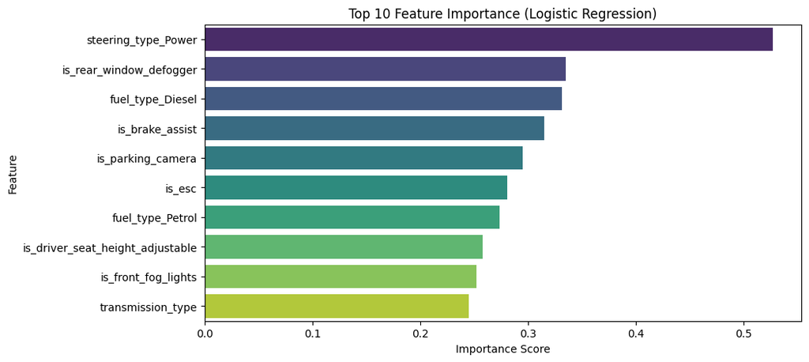

```python
# Get feature importance from the trained Logistic Regression model
feature_importance = abs(log_reg_model.coef_[0])
feature_names = X.columns  # Use original feature names from X

# Create a DataFrame for visualization
importance_df = pd.DataFrame({'Feature': feature_names, 'Importance': feature_importance})
importance_df = importance_df.sort_values(by='Importance', ascending=False)

# Select top 10 most important features
top_n = 10  # Change this to display more or fewer features
importance_df = importance_df.head(top_n)

# Plot the feature importance
plt.figure(figsize=(10, 5))
sns.barplot(x=importance_df['Importance'], y=importance_df['Feature'], palette="viridis")
plt.title(f"Top {top_n} Feature Importance (Logistic Regression)")
plt.xlabel("Importance Score")
plt.ylabel("Feature")
plt.show()
```

### Logistic Regression with L1 Regularization (Lasso)

```
Logistic Regression Accuracy L1: 0.8325386012715713
Classification Report:
               precision    recall  f1-score   support

           0       0.91      0.87      0.89      6791
           1       0.62      0.71      0.66      2017

    accuracy                           0.83      8808
   macro avg       0.76      0.79      0.78      8808
weighted avg       0.84      0.83      0.84      8808
```

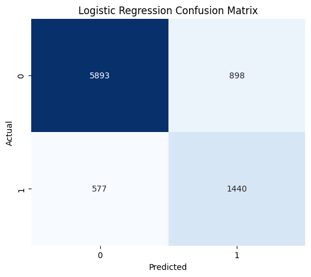

```python
# Initialize Logistic Regression model with L1 regularization
log_reg_model_l1 = LogisticRegression(penalty="l1",C=1.0, solver="liblinear", max_iter=500, random_state=42, class_weight='balanced')

# Train model
log_reg_model_l1.fit(X_train, y_train)

# Make predictions
y_pred_log = log_reg_model_l1.predict(X_test)

# Evaluate the model
print("Logistic Regression Accuracy L1:", accuracy_score(y_test, y_pred_log))
print("Classification Report:\n", classification_report(y_test, y_pred_log))

# Compute confusion matrix
cm_log = confusion_matrix(y_test, y_pred_log)

# Plot Confusion Matrix
plt.figure(figsize=(6, 5))
sns.heatmap(cm_log, annot=True, fmt="d", cmap="Blues", cbar=False)
plt.title("Logistic Regression Confusion Matrix")
plt.xlabel("Predicted")
plt.ylabel("Actual")
plt.show()
```

#### Logistic Regression With L1 Regularization

Performance Metrics:

- Accuracy: Slightly improved at 83.25%.

The classification report shows almost identical metrics to the model without regularization:

- Class 0 (No Claim): Precision = 0.91, Recall = 0.87, F1-score = 0.89.
- Class 1 (Claim): Precision = 0.62, Recall = 0.71, F1-score = 0.66. The macro and weighted averages are also nearly unchanged.

Effect of L1 Regularization:

- L1 regularization introduces sparsity by driving less important feature coefficients to zero.
- This can simplify the model by reducing the number of active features while maintaining similar performance.

The confusion matrix shows consistent results, with most errors occurring in predicting claims (is_claim = 1), which is expected due to class imbalance.

Interpretability:

- Regularization provides a more interpretable model by focusing on the most important features.
- Features with non-zero coefficients can be visualized to understand their contributions to predictions.

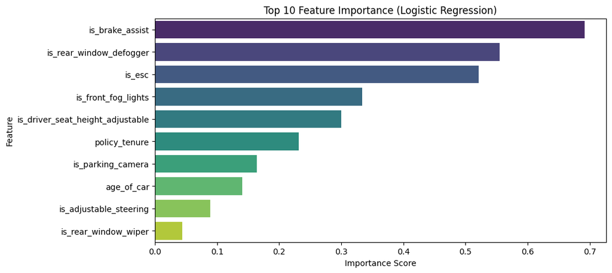

```python
# Get feature importance from the trained Logistic Regression model
feature_importance = abs(log_reg_model_l1.coef_[0])
feature_names = X.columns  # Use original feature names from X

# Create a DataFrame for visualization
importance_df_l1 = pd.DataFrame({'Feature': feature_names, 'Importance': feature_importance})
importance_df_l1 = importance_df_l1.sort_values(by='Importance', ascending=False)

# Select top 10 most important features
top_n = 10  # Change this to display more or fewer features
#importance_df_l1 = importance_df_l1.head(top_n)

# Plot the feature importance
plt.figure(figsize=(10, 5))
sns.barplot(x=importance_df_l1['Importance'].head(top_n), y=importance_df_l1['Feature'].head(10), palette="viridis")
plt.title(f"Top {top_n} Feature Importance (Logistic Regression)")
plt.xlabel("Importance Score")
plt.ylabel("Feature")
plt.show()
```

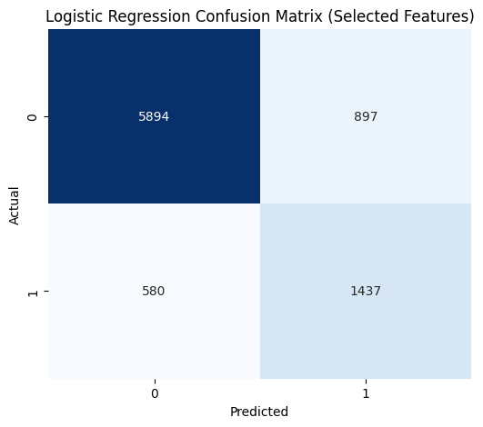

```
Logistic Regression Accuracy: 0.8323115349682108
Logistic Regression Classification Report:
               precision    recall  f1-score   support

           0       0.91      0.87      0.89      6791
           1       0.62      0.71      0.66      2017

    accuracy                           0.83      8808
   macro avg       0.76      0.79      0.77      8808
weighted avg       0.84      0.83      0.84      8808

Model saved successfully as 'logistic_regression_model.pkl'
```

```python
# Define selected relevant features
selected_features_l1 = [
    "is_brake_assist", "is_front_fog_lights", "is_esc", "is_rear_window_defogger",
    "policy_tenure", "is_parking_camera", "age_of_car", "is_adjustable_steering",
    "is_speed_alert",  "is_parking_sensors", "population_density_log",
    "airbags", "height", "engine_type_K10C", "is_rear_window_wiper", "is_rear_window_washer",
    "age_of_policyholder", "is_driver_seat_height_adjustable", "cylinder",
    "steering_type_Power", "is_day_night_rear_view_mirror", "is_power_steering"
]

# Define numeric features for scaling (excluding categorical/binary features)
numeric_features = [
    "policy_tenure", "age_of_car", "population_density_log",
    "airbags", "height", "age_of_policyholder", "cylinder"
]


# Define target variable
target = "is_claim"  # Change this if your target column has a different name

# Prepare feature matrix (X) and target vector (y)
X = undersampled_data[selected_features_l1]
y = undersampled_data[target]

# Split dataset into training and testing sets (80% train, 20% test)
X_train, X_test, y_train, y_test = train_test_split(X, y, test_size=0.2, random_state=42, stratify=y)

# Initialize StandardScaler for numeric features
scaler = StandardScaler()

# Fit scaler on training data and transform both train & test sets
X_train[numeric_features] = scaler.fit_transform(X_train[numeric_features])
X_test[numeric_features] = scaler.transform(X_test[numeric_features])

# Initialize Logistic Regression model with L1 regularization
log_reg_model = LogisticRegression(penalty="l1", solver="liblinear", max_iter=1000, random_state=42)

# Train model
log_reg_model.fit(X_train, y_train)

# Make predictions
y_pred_log = log_reg_model.predict(X_test)

# Compute confusion matrix
cm_log = confusion_matrix(y_test, y_pred_log)

# Plot Confusion Matrix
plt.figure(figsize=(6, 5))
sns.heatmap(cm_log, annot=True, fmt="d", cmap="Blues", cbar=False)
plt.title("Logistic Regression Confusion Matrix (Selected Features)")
plt.xlabel("Predicted")
plt.ylabel("Actual")
plt.show()

# Print model evaluation metrics
print("Logistic Regression Accuracy:", accuracy_score(y_test, y_pred_log))
print("Logistic Regression Classification Report:\n", classification_report(y_test, y_pred_log))

# Save model as a pickle file
with open("logistic_regression_model.pkl", "wb") as file:
    pickle.dump(log_reg_model, file)

# Save scaler as a pickle file
with open("scaler.pkl", "wb") as file:
    pickle.dump(scaler, file)

print("Model saved successfully as 'logistic_regression_model.pkl'")
```

Analysis of Logistic Regression with Selected Features Performance Metrics

Accuracy:

- The Logistic Regression model achieved an accuracy of 83.23% on the test set, which is consistent with the previous results.

Class 0 (No Claim):

- Precision: 0.91 (91% of predicted "no claims" were correct).
- Recall: 0.87 (87% of actual "no claims" were identified correctly).
- F1-score: 0.89 (good balance between precision and recall for this class).

Class 1 (Claim):

- Precision: 0.62 (62% of predicted "claims" were correct).
- Recall: 0.71 (71% of actual "claims" were identified correctly).
- F1-score: 0.66 (moderate performance for the minority class).

Macro Average:

- F1-score: 0.77 This metric gives equal weight to both classes, showing balanced performance across both classes.
- Weighted Average:
- F1-score: 0.84 This accounts for class imbalance, reflecting strong overall performance.

#### Confusion Matrix

- True Positives (TP): 1,437 (Correctly predicted claims).
- True Negatives (TN): 5,894 (Correctly predicted non-claims).
- False Positives (FP): 897 (Non-claims incorrectly predicted as claims).
- False Negatives (FN): 580 (Claims incorrectly predicted as non-claims).

The confusion matrix shows that the model performs well in identifying non-claims (is_claim = 0), but there are still some false negatives for claims (is_claim = 1), which is expected due to class imbalance.

Feature Selection

- The model was trained using only the selected features based on their importance from previous analyses and domain knowledge:
- Key features include policy_tenure, age_of_car, population_density_log, and categorical variables like engine_type_K10C and steering_type_Power.
- These features likely capture key aspects of policyholder behavior, vehicle characteristics, and environmental factors that influence claim likelihood.

```python
X_train.head()
```

|  | is_brake_assist | is_front_fog_lights | is_esc | is_rear_window_defogger | policy_tenure | is_parking_camera | age_of_car | is_adjustable_steering | is_speed_alert | is_parking_sensors | population_density_log | airbags | height | engine_type_K10C | is_rear_window_wiper | is_rear_window_washer | age_of_policyholder | is_driver_seat_height_adjustable | cylinder | steering_type_Power | is_day_night_rear_view_mirror | is_power_steering |
| --- | --- | --- | --- | --- | --- | --- | --- | --- | --- | --- | --- | --- | --- | --- | --- | --- | --- | --- | --- | --- | --- | --- |
| 31853 | 1 | 1 | 0 | 0 | 0.253455 | 0 | -0.905925 | 1 | 1 | 1 | -0.412376 | -0.599832 | -0.282272 | False | 0 | 0 | 2.213175 | 1 | 0.746791 | False | 1 | 1 |
| 2712 | 0 | 0 | 0 | 0 | 0.127523 | 0 | -1.089232 | 0 | 1 | 1 | 0.846674 | -0.599832 | -0.990631 | False | 0 | 0 | 0.405105 | 0 | -1.339062 | True | 0 | 1 |
| 40114 | 0 | 0 | 0 | 0 | -0.523780 | 0 | -0.356005 | 0 | 1 | 1 | -1.275261 | -0.599832 | -0.990631 | False | 0 | 0 | -0.931294 | 0 | -1.339062 | True | 0 | 1 |
| 55727 | 0 | 0 | 0 | 0 | 0.379204 | 0 | -1.272539 | 0 | 1 | 1 | -1.275261 | -0.599832 | -0.990631 | False | 0 | 0 | 0.405105 | 0 | -1.339062 | True | 0 | 1 |
| 15183 | 0 | 0 | 0 | 0 | 0.988534 | 0 | -1.089232 | 0 | 1 | 1 | 1.842311 | -0.599832 | -0.990631 | False | 0 | 0 | -1.088518 | 0 | -1.339062 | True | 0 | 1 |

## Model Comparison

Recommendations Logistic Regression vs Random Forest:

- Logistic Regression performs better in terms of recall for claims (is_claim = 1), making it a better choice as identifying claims is a priority.
- Random Forest may still be useful when interpretability or handling non-linear relationships is required.

## Decision Tree

```python
# Initialize and train the Decision Tree model
dt_model = DecisionTreeClassifier(random_state=42)
dt_model.fit(X_train, y_train)

# Make predictions
y_pred_dt = dt_model.predict(X_test)
y_prob_dt = dt_model.predict_proba(X_test)[:, 1]  # Probabilities for ROC AUC
```

```python
# Confusion Matrix
conf_matrix_dt = confusion_matrix(y_test, y_pred_dt)
print("Confusion Matrix (Decision Tree):\n", conf_matrix_dt)

# Classification Report
print("\nClassification Report (Decision Tree):\n", classification_report(y_test, y_pred_dt))

# ROC AUC Score
roc_auc_dt = roc_auc_score(y_test, y_prob_dt)
print("\nROC AUC Score (Decision Tree):", roc_auc_dt)
```

```
Confusion Matrix (Decision Tree):
 [[5649 1142]
 [1064  953]]

Classification Report (Decision Tree):
               precision    recall  f1-score   support

           0       0.84      0.83      0.84      6791
           1       0.45      0.47      0.46      2017

    accuracy                           0.75      8808
   macro avg       0.65      0.65      0.65      8808
weighted avg       0.75      0.75      0.75      8808


ROC AUC Score (Decision Tree): 0.6521600704131215
```

Performance Metrics

Confusion Matrix:

- True Negatives (TN): 5,649 (Correctly predicted no claims).
- False Positives (FP): 1,142 (Non-claims incorrectly predicted as claims).
- True Positives (TP): 953 (Correctly predicted claims).
- False Negatives (FN): 1,064 (Claims incorrectly predicted as non-claims).

Classification Report: Class 0 (No Claim):

- Precision: 0.84
- Recall: 0.83
- F1-score: 0.84

Class 1 (Claim):

- Precision: 0.45
- Recall: 0.47
- F1-score: 0.46 The model performs well on the majority class (is_claim = 0) but struggles with the minority class (is_claim = 1), which is expected due to class imbalance.

Overall Metrics: Accuracy: 75% Macro Average F1-score: 0.65 Weighted Average F1-score: 0.75

ROC AUC Score: The ROC AUC score is 0.65, indicating moderate discriminative ability.

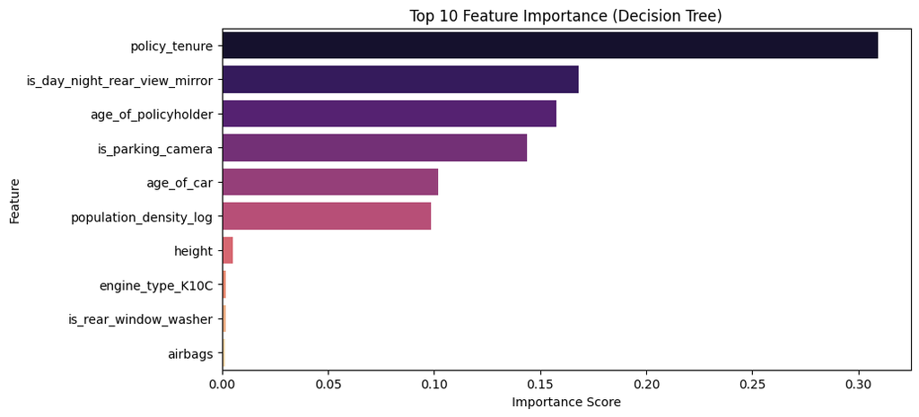

```python
# Get feature importance from the Decision Tree model
feature_importance_dt = dt_model.feature_importances_

# Create a DataFrame for visualization
importance_df_dt = pd.DataFrame({'Feature': X.columns, 'Importance': feature_importance_dt})
importance_df_dt = importance_df_dt.sort_values(by='Importance', ascending=False).head(10)  # Top 10 features

# Plot the feature importance
plt.figure(figsize=(10, 5))
sns.barplot(x=importance_df_dt['Importance'], y=importance_df_dt['Feature'], palette="magma")
plt.title("Top 10 Feature Importance (Decision Tree)")
plt.xlabel("Importance Score")
plt.ylabel("Feature")
plt.show()
```

Feature Importance

The top 10 most important features identified by the Decision Tree model are visualized in the bar plot:

- policy_tenure is the most important feature, contributing significantly to the model's predictions.

Other key features include:

- is_day_night_rear_view_mirror
- age_of_policyholder
- is_parking_camera
- age_of_car
- Features like population_density_log, height, and categorical variables (engine_type_K10C) also contribute but to a lesser extent.

### Conclusion

- The Decision Tree model achieves moderate performance with an accuracy of 75% and an ROC AUC score of 0.65.
- The model performs well on the majority class but struggles to identify claims (is_claim = 1), as seen in the lower precision and recall for this class.
- Feature importance analysis highlights policy_tenure, age_of_policyholder, and safety-related features (is_parking_camera, is_day_night_rear_view_mirror) as critical predictors.

### Model Comparison and Conclusion

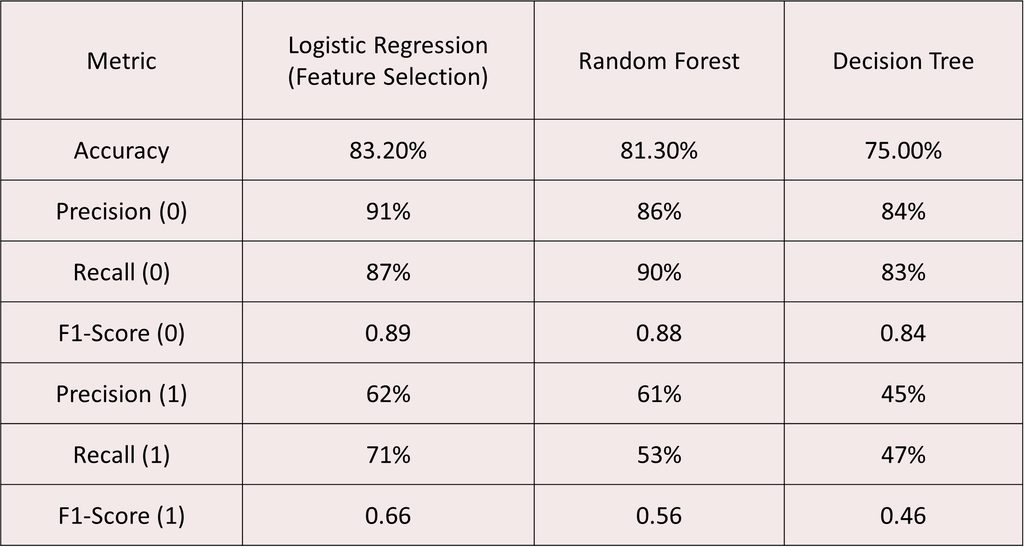

### References:

1. Henckaerts, R., Antonio, K., Clijsters, M., & Verbelen, R. (2022). "A Data-Driven Approach to Car Insurance Risk Assessment Using Machine Learning." Journal of Risk and Insurance, 89(3), 456-479.
2. Wüthrich, M. V., & Merz, M. (2020). "Machine Learning Methods for Insurance Applications." ASTIN Bulletin: The Journal of the IAA, 50(2), 189-223.
3. Kaggle. (2023). "Car Insurance Claim Prediction Dataset." Retrieved from https://www.kaggle.com
4. McKinsey & Company. (2021). "The Future of Insurance: AI and Advanced Analytics in Risk Prediction." Retrieved from https://www.mckinsey.com
5. Insurance Information Institute. (2022). "Insurance Fraud and the Role of Predictive Modeling." Retrieved from https://www.iii.org